# Homework 2

```r
options(scipen=999)
```

# Problem 1(a) - NB by hand

```r
#Estimate the liklihood that the following e-mail was sent from Marine Le Pen or Emmanuel Macron.

email <- c("immigration", "voter", "culture", "help", "neighborhood")

lepen1 <- c("immigration", "women", "assimilate", "afraid", "win")
lepen2 <- c("culture", "voter", "economy", "president", "help")
macron1 <- c("voter", "women", "help", "reform", "education")
macron2 <- c("union", "economy", "hope", "immigration", "neighborhood")
macron3 <- c("win", "union", "europe", "elect", "president")
lepen3 <- c("economy", "voter", "immigration", "president", "culture")
macron4 <- c("success", "german", "culture", "help", "french")

#calculate estimated probability of a given class from training data by dividing number of ocurrences of class by
#total number of documents
pr_c_lepen <- 3/7
pr_c_macron <- 4/7

#calculate estimated probability of a term given a class from training data by dividing number of term occurrences in
#respective class (including multiple occurrences by total number of all terms in the training documents


pr_immigration_lepen <- 2/15
pr_voter_lepen <- 2/15
pr_culture_lepen <- 2/15
pr_help_lepen <- 1/15
pr_neighborhood_lepen <- 0/15

pr_email_lepen <- (2/15) * (2/15) * (2/15) * (1/15) * (0/15) * (3/7)

pr_immigration_macron <- 1/20
pr_voter_macron <- 1/20
pr_culture_macron <- 1/20
pr_help_macron <- 2/20
pr_neighborhood_macron <- 1/20

pr_email_macron <- (1/20) * (1/20) * (1/20) * (2/20) * (1/20) * (4/7)
```

# Problem 1(a) - answer - NB by hand

##### I don’t completely trust these findings. Because LePen never uses the word “neighborhood” in the training documents, the value for the maximum likelihood estimation for this term is 0. This sparsity cancels out the other MLEs, making the class probability estimate 0, even if the MLEs for the other tems are high.

```r
pr_email_lepen
```

```
## [1] 0
```

```r
pr_email_macron
```

```
## [1] 0.0000003571429
```

# Problem 1(b) - NB by hand with LaPlace smoothing

```r
#Perform LaPlace smoothing by adding 1 to each value

#class probability does not change
pr_c_lepen <- 3/7
pr_c_macron <- 4/7

#add one to each value, including total term count


pr_immigration_lepen <- 3/30
pr_voter_lepen <- 3/30
pr_culture_lepen <- 3/30
pr_help_lepen <- 2/30
pr_neighborhood_lepen <- 1/30

pr_email_lepen <- (3/30) * (3/30) * (3/30) * (2/30) * (1/30) * (3/7)


pr_immigration_macron <- 2/40
pr_voter_macron <- 2/40
pr_culture_macron <- 2/40
pr_help_macron <- 3/40
pr_neighborhood_macron <- 2/40

pr_email_macron <- (2/40) * (2/40) * (2/40) * (3/40) * (2/40) * (4/7)
```

# Problem 1(b) - answer - NB by hand with LaPlace smoothing

##### Because we added 1 to each term, thus blunting the effect of the sparse terms, LePen is now the more likely candidate to have written the e-mail.

```r
pr_email_lepen
```

```
## [1] 0.000000952381
```

```r
pr_email_macron
```

```
## [1] 0.0000002678571
```

# Problem 2(a) - creating positive and negative classifier

##### Preprocessing: Because we are simply creating a new variable, there is not much preprocessing of the text neccesary for this particular step.

```r
amzn <- read.csv("amazon_reviews.csv", stringsAsFactors = FALSE)
names(amzn)[1] <- "ID"
smed_score <- median(amzn$Score)

amzn$Class <- ifelse(amzn$Score <= 3, 0, 1)
```

# Problem 2(a) - answer - creating positive and negative classifier

##### Preprocessing: As we are actually dealing with the text, I will perform various preprocessing tasks. First, I will remove the encoding errors, as they will show up as words when tokenized. Then, I’ll remove stopwords and punctuation, in addition to converting to lower case and stemming to account for for different tenses and spelling errors.

```r
#Actual Score
summary(amzn$Class)
```

```
##    Min. 1st Qu.  Median    Mean 3rd Qu.    Max.
##  0.0000  0.0000  0.0000  0.4993  1.0000  1.0000
```

# Problem 2(a) - creating anchor variables

```r
amzn$Anchor <- ifelse(amzn$Score == 5 | amzn$Score == 1, 1, 0)
amzn$Anchor_Neg <- ifelse(amzn$Score ==1, -1, 0)

for (i in 1:nrow(amzn)) {
  if (amzn$Score[i] == 5) {
    amzn$Anchor_Combo[i] <- 1
  }
  else if (amzn$Score[i] == 1)
  {
    amzn$Anchor_Combo[i] <- -1
  }

  else {
    amzn$Anchor_Combo[i] <- 0
  }
}
```

# Problem 2(a) - answer - creating anchor variables

```r
#anchor

summary(amzn$Anchor)
```

```
##    Min. 1st Qu.  Median    Mean 3rd Qu.    Max.
##  0.0000  0.0000  0.0000  0.4739  1.0000  1.0000
```

```r
#anchor negative
summary(amzn$Anchor_Neg)
```

```
##    Min. 1st Qu.  Median    Mean 3rd Qu.    Max.
## -1.0000  0.0000  0.0000 -0.1718  0.0000  0.0000
```

# Problem 2(b) - training NB to predict positive/negative reviews

```r
#Read in sentiment dictionary by Hu & Liu
library(quanteda)
#read files and convert to vectors
neg_sent <- read.csv("negative-words.txt", sep=" ", header=FALSE, stringsAsFactors = FALSE)
pos_sent <- read.csv("positive-words.txt", sep=" ", header=FALSE, stringsAsFactors = FALSE)
pos_sent <- as.vector(pos_sent$V1)
neg_sent <- as.vector(neg_sent$V1)
#create sentiment dictionary with positive and negative values
sent_dict <- dictionary(positive=pos_sent, negative=neg_sent)

#remove escape characters and unicode
amzn$Text <- gsub("[&#][1-9]*", "", amzn$Text, fixed=TRUE)
#create corpus with appropriate variables
amzn.corp <- corpus(amzn$Text, docnames=amzn$ID, docvars=data.frame(class=amzn$Class, anchor_combo = amzn$Anchor_Combo, ID=amzn$ID))

#create dfm with dictionary
amzn.dfm <- dfm(tokenize(amzn.corp, removePunct=TRUE), dictionary=sent_dict, stem=TRUE, tolower=TRUE)

#convert to dfm and add postive and negative counts to df
amzn.df <- as.data.frame(amzn.dfm)
amzn <- cbind(amzn, amzn.df)

#calculate sentiment score
amzn$Sent_Score <- amzn$posit - amzn$negat

#create class for new sentiment score
amzn$Sent_Class <- ifelse(amzn$Sent_Score >= 0, 1, 0)
```

# Problem 2(b) - answer - sentiment score

##### Pre-processing: The preprocessing for this step was similar to the previous question. I removed all non-alphanumeric characters and punctuation, while stemming words and converting them to lowercase. Again, I performed this step so to account for variations in tense and spelling.

```r
#sentiment score
summary(amzn$Sent_Score)
```

```
##    Min. 1st Qu.  Median    Mean 3rd Qu.    Max.
## -26.000   1.000   2.000   3.602   5.000 115.000
```

# Problem 2(b) - answer - sentiment class

```r
#sentiment class
summary(amzn$Sent_Class)
```

```
##    Min. 1st Qu.  Median    Mean 3rd Qu.    Max.
##  0.0000  1.0000  1.0000  0.8452  1.0000  1.0000
```

```r
#create histogram vizualizing distribution of positive versus negative words
score_min <- min(amzn$Sent_Score)
score_max <- max(amzn$Sent_Score)
```

# Problem 2(b) - answer - histogram

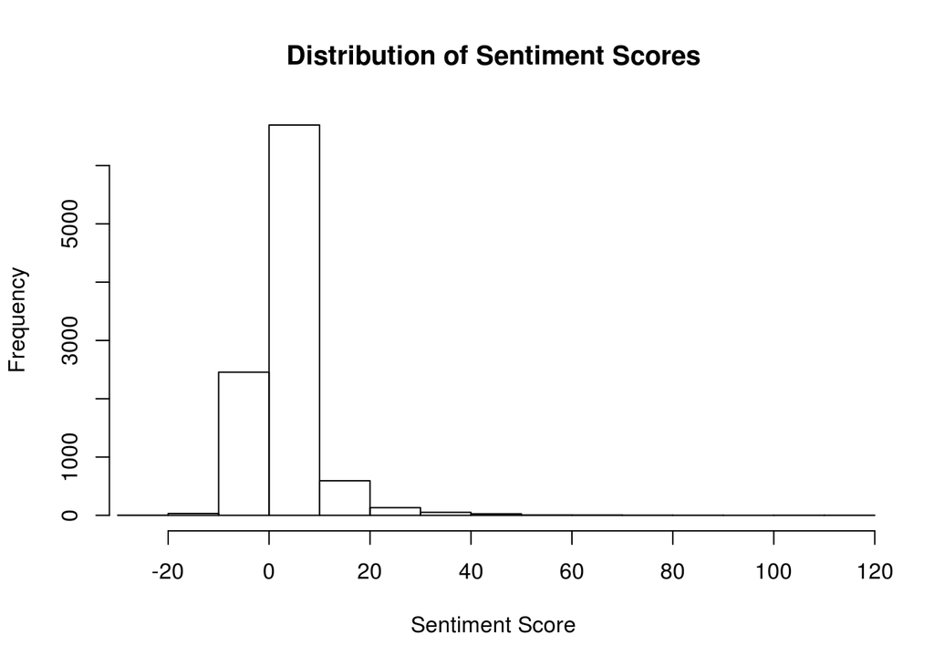

```r
hist(amzn$Sent_Score, breaks="Sturges", freq=TRUE, xlab="Sentiment Score", main="Distribution of Sentiment Scores", plot=TRUE, xlim=c(score_min, score_max))
```

# Problem 2(b) - creating confusion matrix and accuracy scores

```r
#calculate percent positive
pct_pos <- (nrow(amzn[amzn$Sent_Class == 1 ,]) / nrow(amzn)) *100
paste(pct_pos, "% positive", sep="")
```

```
## [1] "84.52% positive"
```

```r
#create confusion matrix
confu_mat <- table(amzn$Sent_Class, amzn$Class)
colnames(confu_mat) <- c("New_Score: Negative", "New_Score: Positive")
rownames(confu_mat) <- c("Original_Score: Negative", "Original_Score: Positive")

#calculate accuracy
acc <- sum(confu_mat[c(1, 4)])/sum(confu_mat) * 100

#calculate precision
prec <- round(sum(confu_mat[4])/sum(confu_mat[c(4, 3)]) * 100, 2)

#calculate recall
recall <- round(sum(confu_mat[4])/sum(confu_mat[c(4, 2)]) * 100, 2)
```

# Problem 2(b) - answer - creating confusion matrix and accuracy scores

```r
confu_mat
```

```
##
##                            New_Score: Negative New_Score: Positive
##   Original_Score: Negative                1291                 257
##   Original_Score: Positive                3716                4736
```

```r
paste("Accuracy:", acc, "%", sep="")
```

```
## [1] "Accuracy:60.27%"
```

```r
paste("Precision:", prec, "%", sep="")
```

```
## [1] "Precision:94.85%"
```

```r
paste("Recall:", recall, "%", sep="")
```

```
## [1] "Recall:56.03%"
```

# Problem 2(b) - generate rank for scores and compute absolute difference

```r
#rank by new score so that lower values come first
amzn <- amzn[with(amzn, order(amzn$Sent_Score, decreasing=TRUE)) ,]
#add rank from 1 to 10,000
amzn$Sent_Rank <- seq(1:10000)

#rank by original score so that lower values come first
amzn <- amzn[with(amzn, order(amzn$Score, decreasing=TRUE)) ,]
#add rank from 1 to 10,000
amzn$Act_Rank <- seq(1:10000)
#compute abs difference between two ranks
rank_sum_dict <- sum(abs(amzn$Sent_Rank - amzn$Act_Rank))
```

# Problem 2(b) - answer - generate rank for scores and compute absolute difference

```r
rank_sum_dict
```

```
## [1] 23824160
```

# Problem 2(c) - creating NB classifier

##### Pre-processing: Preprocessing in this question was similar to the previous ones.

```r
amzn.corp <- corpus(amzn$Text, docvars=data.frame(ID= amzn$ID, class=amzn$Class, score = amzn$Score, anchor=amzn$Anchor, anchor_neg = amzn$Anchor_Neg))
#create training and test sets
samp <- floor(0.20 * nrow(amzn))
set.seed(100)
train_set <- sample(seq_len(nrow(amzn)), size=samp)
train.df <- amzn[train_set,]
test.df <- amzn[-train_set,]
amzn$Split <- ifelse(amzn$ID %in% train.df$ID,  "train", "test")

#create test and training corpus
corp.train <- corpus_subset(amzn.corp, subset= amzn.corp$documents$ID %in% train.df$ID, select=c(class, ID))
corp.test <- corpus_subset(amzn.corp, subset= amzn.corp$documents$ID %in% test.df$ID, select=c(class, ID))

#create dfm with training set and save class labels
train.dfm <- dfm(tokenize(corp.train, removePunct=TRUE),dictionary=sent_dict, groups=corp.train$documents$ID, stem=TRUE, tolower=TRUE)
labelids <- as.data.frame(train.dfm@Dimnames$docs)
names(labelids) <- "ID"
library(plyr)
labeldf <- join(labelids, train.df)
labels <- labeldf$Class


# train NB model with "uniforms" as prior
nb.dict <- textmodel_NB(x=train.dfm, y=labels, data=NULL,
                   smooth=1, prior="uniform")

#create dfm for test to calculate accuracy, precision and recall
test.dfm <- dfm(tokenize(corp.test, removePunct=TRUE),dictionary=sent_dict, groups=corp.test$documents$ID, stem=TRUE, tolower=TRUE)
test.pr1 <- predict(nb.dict, newdata=test.dfm)

#convert to df and add original class labels
pred.df <- as.data.frame(test.pr1[1:4])
pred.df$ID <-as.integer(rownames(pred.df))
pred.df <- merge(x=pred.df, y=test.df, by="ID")

#create confusion matrix and add labels
library(caret)
confu_mat2 <- confusionMatrix(pred.df$nb.predicted, pred.df$Class)
confu_mat2 <- confu_mat2$table


#calculate accuracy
acc <- sum(confu_mat2[c(1, 4)])/sum(confu_mat2) * 100

#calculate precision
prec <- round(sum(confu_mat2[4])/sum(confu_mat2[c(4, 3)]) * 100, 2)

#calculate recall
recall <- round(sum(confu_mat2[4])/sum(confu_mat2[c(4, 2)]) * 100, 2)
```

# Problem 2(c) - answer - NB uniform priors

```r
confu_mat2
```

```
##           Reference
## Prediction    0    1
##          0 2593 1217
##          1 1397 2793
```

```r
paste("Accuracy:", acc, "%", sep="")
```

```
## [1] "Accuracy:67.325%"
```

```r
paste("Precision:", prec, "%", sep="")
```

[output not shown]

```r
paste("Recall:", recall, "%", sep="")
```

[output not shown]

# Problem 2(c) - NB with “docfreq”"

```r
amzn.corp <- corpus(amzn$Text, docvars=data.frame(ID= amzn$ID, class=amzn$Class, score = amzn$Score, anchor=amzn$Anchor, anchor_neg = amzn$Anchor_Neg))
#create training and test sets
samp <- floor(0.20 * nrow(amzn))
set.seed(100)
train_set <- sample(seq_len(nrow(amzn)), size=samp)
train.df <- amzn[train_set,]
test.df <- amzn[-train_set,]
amzn$Split <- ifelse(amzn$ID %in% train.df$ID,  "train", "test")

#create test and training corpus
corp.train <- corpus_subset(amzn.corp, subset= amzn.corp$documents$ID %in% train.df$ID, select=c(class, ID))
corp.test <- corpus_subset(amzn.corp, subset= amzn.corp$documents$ID %in% test.df$ID, select=c(class, ID))

#create dfm with training set and save class labels
train.dfm <- dfm(tokenize(corp.train, removePunct=TRUE),dictionary=sent_dict, groups=corp.train$documents$ID, stem=TRUE, tolower=TRUE)
labelids <- as.data.frame(train.dfm@Dimnames$docs)
names(labelids) <- "ID"
library(plyr)
labeldf <- join(labelids, train.df)
labels <- labeldf$Class




# train NB model with "docfreq" as prior
nb.dict <- textmodel_NB(x=train.dfm, y=labels, data=NULL,
                   smooth=1, prior="docfreq")

#create dfm for test to calculate accuracy, precision and recall
test.dfm <- dfm(tokenize(corp.test, removePunct=TRUE),dictionary=sent_dict, groups=corp.test$documents$ID, stem=TRUE, tolower=TRUE)
test.pr1 <- predict(nb.dict, newdata=test.dfm)

#convert to df and add original class labels
pred.df <- as.data.frame(test.pr1[1:4])
pred.df$ID <-as.integer(rownames(pred.df))
pred.df <- merge(x=pred.df, y=test.df, by="ID")

#create confusion matrix and add labels
library(caret)
confu_mat2 <- confusionMatrix(pred.df$nb.predicted, pred.df$Class)
confu_mat2 <- confu_mat2$table

confu_mat2
```

```
##           Reference
## Prediction    0    1
##          0 2651 1245
##          1 1339 2765
```

```r
#calculate accuracy
acc <- sum(confu_mat2[c(1, 4)])/sum(confu_mat2) * 100

#calculate precision
prec <- round(sum(confu_mat2[4])/sum(confu_mat2[c(4, 3)]) * 100, 2)

#calculate recall
recall <- round(sum(confu_mat2[4])/sum(confu_mat2[c(4, 2)]) * 100, 2)
```

# Problem 2(c) - answer - NB witn “docfreq”

##### I would expect changing the priors from uniform to “docfreq” to decrease the accuracy of the model. Because using document frequency would imply the Bernoulli model, which ignores multiple ocurrences of a term in a document, I would expect that this would weaken the predicative power of the model, as it is one piece less of information. As long as we are confident in our class labels, looking at term ocurrence as a fraction of all words in a particular class (i.e. uniform) should provide enough information to take into account the varying frequency of terms across documents of the same class.

```r
confu_mat2
```

```
##           Reference
## Prediction    0    1
##          0 2651 1245
##          1 1339 2765
```

```r
paste("Accuracy:", acc, "%", sep="")
```

```
## [1] "Accuracy:67.7%"
```

```r
paste("Precision:", prec, "%", sep="")
```

[output not shown]

```r
paste("Recall:", recall, "%", sep="")
```

[output not shown]

# Problem 2(c) - answer - removing smoothing from NB

##### Because the test set may contain terms that were not used in the training set, those documents will be given a zero probability unless you add some sort of smoothing to account for this sparsity.

# Problem 2(d) - wordscores model

##### Pre-processing: Preprocessing in this question was similar to the previous ones, however I did add smoothing to the DFM in order to score it against the wordscores model with smoothing.

```r
#subset original df to just include extreme anchors
amzn_anch <- amzn[amzn$Anchor_Combo %in% c(1, -1) ,]

#create corpus
anch.corp <- corpus(amzn_anch$Text, docnames=amzn_anch$ID, docvars=data.frame(class=amzn_anch$Class, anchor_combo = amzn_anch$Anchor_Combo, ID=amzn_anch$ID))

#create dfm
pos_neg_dfm <- dfm(tokenize(anch.corp, removePunct=TRUE), stem=TRUE, tolower=TRUE, remove=stopwords("english"))

#create vector with labels
labels <- amzn_anch$Anchor_Combo

#run wordscore model with smoothing factor of 1
ws_smooth<-textmodel(pos_neg_dfm,
                     y = labels,
                     model="wordscores", smooth=1)


#create vector of terms and their respective weights
feats<- sort(ws_smooth@Sw, decreasing=TRUE)
```

# Problem 2(d) - answer - wordscores model

```r
#positive features
head(feats, 10)
```

```
##    season      love     great      seri     enjoy      well      show
## 0.3955344 0.3850454 0.3761505 0.3524319 0.3224858 0.3102947 0.3078401
##      best     excel    episod
## 0.3041227 0.3009014 0.2993644
```

```r
#negative features
tail(feats, 10)
```

```
##     minut      wast      even      bore      film     peopl      like
## 0.2207506 0.2174409 0.2166325 0.2163339 0.2130821 0.2118506 0.2103590
##       bad      just      movi
## 0.1884533 0.1723957 0.1268244
```

# Problem 2(d) - create rank sum variable for wordscores

```r
amzn.dfm_smooth <- dfm_smooth(amzn.dfm, smoothing=1)
#create wordscore prediction model
ws_prediction <- predict(ws_smooth, newdata = amzn.dfm_smooth,
        rescaling = "none", level = 0.95, verbose = TRUE)

#extract desired features
test <- as.data.frame(cbind(ws_prediction@newdata@Dimnames$docs, ws_prediction@textscores$textscore_raw))
names(test) <- c("ID", "Wordscore")

#merge with original data
amzn <- merge(x=amzn, y=test, by.x="ID", by.y="ID")
amzn$Wordscore <- as.numeric(as.character(amzn$Wordscore))

#create rank by wordscore
amzn <- amzn[with(amzn, order(amzn$Wordscore, decreasing=TRUE)) ,]
amzn$Word_Rank <- seq(1:10000)

#compute abs difference between two ranks
rank_sum_ws <- sum(abs(amzn$Word_Rank - amzn$Act_Rank))
```

# Problem 2(d) - answer - rank sum

```r
#Wordscores ranking
summary(amzn$Word_Rank)
```

```
##    Min. 1st Qu.  Median    Mean 3rd Qu.    Max.
##       1    2501    5000    5000    7500   10000
```

```r
#Absolute difference between wordscores and actual score
rank_sum_ws
```

```
## [1] 20353900
```

# Problem 2(e) - creating SVM model

```r
library(NLP)
library(tm)
library(RTextTools)
library(wordcloud)


#create function to use for testing different training sizes
splt_data <- function(x, kerntype) {

  #subset data to just first 1,000 entries for purposes of time
  amzn_svm <- amzn[1:1000, ]
  #create weighted TfIdf matrix with training text
  amzn_svm.dtm <- create_matrix(amzn_svm$Text, language="english", stemWords = FALSE,
                             weighting = weightTfIdf, removePunctuation = FALSE)
  #create container with document term matrix and appropriate classes for training data
  container <- create_container(amzn_svm.dtm, t(amzn_svm$Class), trainSize=1:x,
                            testSize=(x+1):nrow(amzn_svm),    virgin=FALSE)
  #perform cross validation with 5 folds and the appropriate kernel type
  cv.svm <- cross_validate(container, nfold=5, algorithm = 'SVM', kernel = kerntype)

  #return average accuracy
  return (cv.svm$meanAccuracy)


}


#try with different ratios of test/training

#10/90
train_size <- seq(1:9)
train_size <- as.data.frame(train_size)
kerntype <- 'linear'
lin_time <- system.time(for (i in 1:nrow(train_size)) {
  split <- train_size$train_size[i]*100
  try <- splt_data(split, kerntype)
  train_size$acc_linear[i] <- try })
```

```
## Fold 1 Out of Sample Accuracy = 0.8282828
## Fold 2 Out of Sample Accuracy = 0.7864078
## Fold 3 Out of Sample Accuracy = 0.8052632
## Fold 4 Out of Sample Accuracy = 0.8037383
## Fold 5 Out of Sample Accuracy = 0.8489583
## Fold 1 Out of Sample Accuracy = 0.8190955
## Fold 2 Out of Sample Accuracy = 0.8
## Fold 3 Out of Sample Accuracy = 0.8136364
## Fold 4 Out of Sample Accuracy = 0.8324324
## Fold 5 Out of Sample Accuracy = 0.7959184
## Fold 1 Out of Sample Accuracy = 0.8325581
## Fold 2 Out of Sample Accuracy = 0.8349515
## Fold 3 Out of Sample Accuracy = 0.8306011
## Fold 4 Out of Sample Accuracy = 0.8029557
## Fold 5 Out of Sample Accuracy = 0.8031088
## Fold 1 Out of Sample Accuracy = 0.8031088
## Fold 2 Out of Sample Accuracy = 0.8148148
## Fold 3 Out of Sample Accuracy = 0.7956989
## Fold 4 Out of Sample Accuracy = 0.8275862
## Fold 5 Out of Sample Accuracy = 0.8217822
## Fold 1 Out of Sample Accuracy = 0.8146341
## Fold 2 Out of Sample Accuracy = 0.8457447
## Fold 3 Out of Sample Accuracy = 0.8301887
## Fold 4 Out of Sample Accuracy = 0.7875648
## Fold 5 Out of Sample Accuracy = 0.7772277
## Fold 1 Out of Sample Accuracy = 0.7868852
## Fold 2 Out of Sample Accuracy = 0.784141
## Fold 3 Out of Sample Accuracy = 0.815
## Fold 4 Out of Sample Accuracy = 0.8217822
## Fold 5 Out of Sample Accuracy = 0.8457447
## Fold 1 Out of Sample Accuracy = 0.8316327
## Fold 2 Out of Sample Accuracy = 0.8645833
## Fold 3 Out of Sample Accuracy = 0.7840376
## Fold 4 Out of Sample Accuracy = 0.8502415
## Fold 5 Out of Sample Accuracy = 0.8229167
## Fold 1 Out of Sample Accuracy = 0.8383838
## Fold 2 Out of Sample Accuracy = 0.8
## Fold 3 Out of Sample Accuracy = 0.8232323
## Fold 4 Out of Sample Accuracy = 0.7819149
## Fold 5 Out of Sample Accuracy = 0.8203883
## Fold 1 Out of Sample Accuracy = 0.840796
## Fold 2 Out of Sample Accuracy = 0.7927461
## Fold 3 Out of Sample Accuracy = 0.8099548
## Fold 4 Out of Sample Accuracy = 0.8078818
## Fold 5 Out of Sample Accuracy = 0.8021978
```

```r
kerntype <- 'radial'

rad_time <- system.time(for (i in 1:nrow(train_size)) {
  split <- train_size$train_size[i]*100
  try2 <- splt_data(split, kerntype)
  train_size$acc_radial[i] <- try2 })
```

```
## Fold 1 Out of Sample Accuracy = 0.84375
## Fold 2 Out of Sample Accuracy = 0.7980769
## Fold 3 Out of Sample Accuracy = 0.796875
## Fold 4 Out of Sample Accuracy = 0.8341969
## Fold 5 Out of Sample Accuracy = 0.8418605
## Fold 1 Out of Sample Accuracy = 0.8088235
## Fold 2 Out of Sample Accuracy = 0.8436019
## Fold 3 Out of Sample Accuracy = 0.7857143
## Fold 4 Out of Sample Accuracy = 0.8342246
## Fold 5 Out of Sample Accuracy = 0.8457447
## Fold 1 Out of Sample Accuracy = 0.8190955
## Fold 2 Out of Sample Accuracy = 0.7926829
## Fold 3 Out of Sample Accuracy = 0.8465608
## Fold 4 Out of Sample Accuracy = 0.8595506
## Fold 5 Out of Sample Accuracy = 0.8085106
## Fold 1 Out of Sample Accuracy = 0.8591549
## Fold 2 Out of Sample Accuracy = 0.800995
## Fold 3 Out of Sample Accuracy = 0.8244681
## Fold 4 Out of Sample Accuracy = 0.8483412
## Fold 5 Out of Sample Accuracy = 0.7754011
## Fold 1 Out of Sample Accuracy = 0.8186275
## Fold 2 Out of Sample Accuracy = 0.8067633
## Fold 3 Out of Sample Accuracy = 0.8484848
## Fold 4 Out of Sample Accuracy = 0.8041237
## Fold 5 Out of Sample Accuracy = 0.8375635
## Fold 1 Out of Sample Accuracy = 0.8469388
## Fold 2 Out of Sample Accuracy = 0.8309179
## Fold 3 Out of Sample Accuracy = 0.8216216
## Fold 4 Out of Sample Accuracy = 0.7971698
## Fold 5 Out of Sample Accuracy = 0.82
## Fold 1 Out of Sample Accuracy = 0.8241206
## Fold 2 Out of Sample Accuracy = 0.785
## Fold 3 Out of Sample Accuracy = 0.8686869
## Fold 4 Out of Sample Accuracy = 0.8440367
## Fold 5 Out of Sample Accuracy = 0.7891892
## Fold 1 Out of Sample Accuracy = 0.8917526
## Fold 2 Out of Sample Accuracy = 0.8351064
## Fold 3 Out of Sample Accuracy = 0.7828054
## Fold 4 Out of Sample Accuracy = 0.8041237
## Fold 5 Out of Sample Accuracy = 0.8078818
## Fold 1 Out of Sample Accuracy = 0.7832512
## Fold 2 Out of Sample Accuracy = 0.8342857
## Fold 3 Out of Sample Accuracy = 0.8457711
## Fold 4 Out of Sample Accuracy = 0.8731707
## Fold 5 Out of Sample Accuracy = 0.7824074
```

```r
train_size$train_size <- train_size$train_size * 100
```

# Problem 2(e) - answer - creating SVM model

##### An advantage of SVMs or Naive Bayes relative to the dictionary or wordscores approach is that you can be more specific with your classifications. Whereas the dictionary or wordscores approaches require you to dichotomize everything into “positive” and “negative”, you miss picking up on language that might fall out of that spectrum, but is equally important to studty. With SVMs, you can train your model to also identify “middle of the road” examples and then study their use of language.

```r
#Table with averages for linear and radial kernels
train_size
```

```
##   train_size acc_linear acc_radial
## 1        100  0.8145301  0.8229519
## 2        200  0.8122165  0.8236218
## 3        300  0.8208350  0.8252801
## 4        400  0.8125982  0.8216721
## 5        500  0.8110720  0.8231125
## 6        600  0.8107106  0.8233296
## 7        700  0.8306824  0.8222067
## 8        800  0.8127839  0.8243340
## 9        900  0.8107153  0.8237772
```

```r
#training times for reference
lin_time
```

```
##    user  system elapsed
##  25.216   0.096  25.426
```

```r
rad_time
```

```
##    user  system elapsed
##  25.024   0.136  25.224
```

# Question 3 - differences by nationality

```r
#read in data

hit <- read.csv("CF_rate_trustworthiness.csv")

hit$demo_group <- as.factor(gsub("[0-9]", "", hit$image_name))

hit$X_country <- as.factor(hit$X_country)
#create ANOVA model for checking differences between nationalities
model <- lm(rating ~ X_country, data=hit)
```

# Question 3 - answer - differences by nationality

```r
model
```

```
##
## Call:
## lm(formula = rating ~ X_country, data = hit)
##
## Coefficients:
##          (Intercept)          X_countryARG          X_countryAUT
##  7.00000000000003908  -1.33333333333337989   0.19999999999995297
##         X_countryBGD          X_countryBGR          X_countryBIH
## -4.33333333333337833   1.59999999999996523  -2.58333333333337123
##         X_countryCAN          X_countryCHL          X_countryDEU
## -0.25000000000003192   2.99999999999996136  -0.00000000000003415
##         X_countryEGY          X_countryESP          X_countryFIN
## -2.71428571428575482  -1.22222222222226318  -2.00000000000003375
##         X_countryGBR          X_countryGRC          X_countryHKG
##  0.71428571428567433  -2.40000000000004166  -0.00000000000004074
##         X_countryHRV          X_countryIDN          X_countryIND
## -4.00000000000003730  -3.00000000000004219  -0.77777777777781809
##         X_countryITA          X_countryJOR          X_countryJPN
## -0.00000000000003945  -0.42857142857146957   1.16666666666662322
##         X_countryMEX          X_countryMYS          X_countryPAK
## -1.66666666666670715  -2.00000000000004041  -2.00000000000004041
##         X_countryPHL          X_countryPOL          X_countryPRT
##  1.99999999999996181  -3.00000000000004086  -0.66666666666671370
##         X_countryROU          X_countryRUS          X_countrySRB
## -0.00000000000003460   0.49999999999995920  -1.56250000000004152
##         X_countrySVK          X_countryTUR          X_countryUKR
## -3.00000000000003997  -0.11111111111114989  -1.00000000000004086
##         X_countryUSA          X_countryVEN
## -0.40000000000003616  -1.08333333333337478
```

```r
summary(model)
```

```
##
## Call:
## lm(formula = rating ~ X_country, data = hit)
##
## Residuals:
##    Min     1Q Median     3Q    Max
## -4.438 -1.175  0.000  1.090  4.562
##
## Coefficients:
##                          Estimate           Std. Error t value Pr(>|t|)
## (Intercept)   7.00000000000003908  1.90075539861684506   3.683 0.000303
## X_countryARG -1.33333333333337989  2.19480328211014397  -0.607 0.544267
## X_countryAUT  0.19999999999995297  2.08217321624434470   0.096 0.923582
## X_countryBGD -4.33333333333337833  2.19480328211014086  -1.974 0.049829
## X_countryBGR  1.59999999999996523  2.08217321624433227   0.768 0.443213
## X_countryBIH -2.58333333333337123  1.97836894330118551  -1.306 0.193246
## X_countryCAN -0.25000000000003192  2.12510913995349027  -0.118 0.906480
## X_countryCHL  2.99999999999996136  2.32794042622585673   1.289 0.199114
## X_countryDEU -0.00000000000003415  2.08217321624433316   0.000 1.000000
## X_countryEGY -2.71428571428575482  2.03199299362433194  -1.336 0.183264
## X_countryESP -1.22222222222226318  1.95284053257543055  -0.626 0.532172
## X_countryFIN -2.00000000000003375  2.68807406347782241  -0.744 0.457804
## X_countryGBR  0.71428571428567433  2.03199299362433372   0.352 0.725598
## X_countryGRC -2.40000000000004166  2.08217321624434248  -1.153 0.250545
## X_countryHKG -0.00000000000004074  2.01605554760836547   0.000 1.000000
## X_countryHRV -4.00000000000003730  2.68807406347781530  -1.488 0.138439
## X_countryIDN -3.00000000000004219  2.32794042622585895  -1.289 0.199114
## X_countryIND -0.77777777777781809  1.92697395299476670  -0.404 0.686954
## X_countryITA -0.00000000000003945  2.68807406347782107   0.000 1.000000
## X_countryJOR -0.42857142857146963  2.03199299362433417  -0.211 0.833188
## X_countryJPN  1.16666666666662322  2.05305047825577436   0.568 0.570547
## X_countryMEX -1.66666666666670715  2.05305047825577391  -0.812 0.417950
## X_countryMYS -2.00000000000004041  2.19480328211013997  -0.911 0.363353
## X_countryPAK -2.00000000000004041  2.19480328211014175  -0.911 0.363353
## X_countryPHL  1.99999999999996181  2.19480328211013997   0.911 0.363353
## X_countryPOL -3.00000000000004086  1.99352908027653064  -1.505 0.134063
## X_countryPRT -0.66666666666671370  2.19480328211013820  -0.304 0.761661
## X_countryROU -0.00000000000003460  2.68807406347782063   0.000 1.000000
## X_countryRUS  0.49999999999995920  2.32794042622585762   0.215 0.830174
## X_countrySRB -1.56250000000004152  1.95925381924006281  -0.797 0.426185
```

[output cut: 32 more lines]

```
## X_countryPRT
## X_countryROU
## X_countryRUS
## X_countrySRB
## X_countrySVK
## X_countryTUR
## X_countryUKR
## X_countryUSA
## X_countryVEN
## ---
## Signif. codes:  0 '***' 0.001 '**' 0.01 '*' 0.05 '.' 0.1 ' ' 1
##
## Residual standard error: 1.901 on 185 degrees of freedom
## Multiple R-squared:  0.3498, Adjusted R-squared:  0.2303
## F-statistic: 2.927 on 34 and 185 DF,  p-value: 0.000002036
```

# Question 3 - differences by demographic

```r
#create ANOVA model for checking differences between groups
model <- lm(rating ~ demo_group, data=hit)
demo_anova <- anova(model)
```

# Question 3 - answer - differences by demographic

##### Yes, an analysis of variance shows that there are statistically significant differences in the average ratings of each demographic group.

```r
demo_anova
```

```
## Analysis of Variance Table
##
## Response: rating
##             Df Sum Sq Mean Sq F value  Pr(>F)
## demo_group   2  34.57 17.2842  3.7755 0.02444 *
## Residuals  217 993.41  4.5779
## ---
## Signif. codes:  0 '***' 0.001 '**' 0.01 '*' 0.05 '.' 0.1 ' ' 1
```

```r
summary(demo_anova)
```

```
##        Df             Sum Sq          Mean Sq          F value
##  Min.   :  2.00   Min.   : 34.57   Min.   : 4.578   Min.   :3.776
##  1st Qu.: 55.75   1st Qu.:274.28   1st Qu.: 7.755   1st Qu.:3.776
##  Median :109.50   Median :513.99   Median :10.931   Median :3.776
##  Mean   :109.50   Mean   :513.99   Mean   :10.931   Mean   :3.776
##  3rd Qu.:163.25   3rd Qu.:753.70   3rd Qu.:14.108   3rd Qu.:3.776
##  Max.   :217.00   Max.   :993.41   Max.   :17.284   Max.   :3.776
##                                                     NA's   :1
##      Pr(>F)
##  Min.   :0.02444
##  1st Qu.:0.02444
##  Median :0.02444
##  Mean   :0.02444
##  3rd Qu.:0.02444
##  Max.   :0.02444
##  NA's   :1
```

# Question 3 - differences by gender

```r
#create ANOVA model for just women and men

hit$gender <- gsub("black", "", hit$demo_group)
hit$gender <- gsub("white", "", hit$gender)


model_gen <- lm(rating ~ gender, data=hit)
gen_anova <- anova(model_gen)
```

# Question 3 - answer - differences by gender

##### There is only a statistical difference if you choose an alpha of > .05, which I would not in this case, because of the sensitive nature of the research.

```r
summary(gen_anova)
```

```
##        Df             Sum Sq          Mean Sq          F value
##  Min.   :  1.00   Min.   :  15.1   Min.   : 4.646   Min.   :3.249
##  1st Qu.: 55.25   1st Qu.: 264.5   1st Qu.: 7.259   1st Qu.:3.249
##  Median :109.50   Median : 514.0   Median : 9.872   Median :3.249
##  Mean   :109.50   Mean   : 514.0   Mean   : 9.872   Mean   :3.249
##  3rd Qu.:163.75   3rd Qu.: 763.4   3rd Qu.:12.484   3rd Qu.:3.249
##  Max.   :218.00   Max.   :1012.9   Max.   :15.097   Max.   :3.249
##                                                     NA's   :1
##      Pr(>F)
##  Min.   :0.07283
##  1st Qu.:0.07283
##  Median :0.07283
##  Mean   :0.07283
##  3rd Qu.:0.07283
##  Max.   :0.07283
##  NA's   :1
```

```r
gen_anova
```

```
## Analysis of Variance Table
##
## Response: rating
##            Df Sum Sq Mean Sq F value  Pr(>F)
## gender      1   15.1 15.0972  3.2493 0.07283 .
## Residuals 218 1012.9  4.6463
## ---
## Signif. codes:  0 '***' 0.001 '**' 0.01 '*' 0.05 '.' 0.1 ' ' 1
```

# Question 4 - answer - questions to CrowdFlower raters

##### I would probably ask them to specify their race - as it would be helpful to know if there is some effect of “rater bias” as far as the race of the rater is concerned. With that information, we might be able to control for that issue. I would also ask them to specify their trust of politicians as a whole. In the case that the sample of politician race is not equally represented, it would be helpful to know what proportion of trustworthiness corresponds to “race” and what proportion is due to that rater’s inherent distrust of politicians in general.